# Titanic Passenger Data: Exploratory Analysis

Richard Kublik

[figure not shown]

As an introductory data science project, I have chosen to explore the data provided by the [Titanic: Machine Learning from Disaster](https://www.kaggle.com/c/titanic) competition hosted by Kaggle. The competition is to build the best model that can predict whether a given passenger survived the sinking of the Titanic. As a first step, I wanted to learn more about the passengers on board.

# The Data

Kaggle has split the passenger data into 2 subsets. Both data sets contain information about the gender, travel class, age, etc. for each passenger. The training data also indicates if the passenger survived or not, while the test data set does not. For this exploratory analysis, I am interested in learning about all of the passengers, and will be working with the combined data set.

We begin by loading the required packages:

```r
library(readr)
library(dplyr)
library(tidyr)
library(ggplot2)
library(ggmosaic)
library(stringr)

# set random number generator seed so analysis is repeatable
set.seed(9516549)
```

Next, we read the data files, and combine them into a single data frame. We also do some initial pre-processing to define categorical values for some of the variables.

```r
train_data <- read_csv(file.path('..','data','train.csv'))
test_data <-  read_csv(file.path('..','data','test.csv'))
```

```r
# Merge datasets, initial pre-processing
titanic_data <- train_data %>%
  select(-Survived) %>%
  bind_rows(test_data) %>%
  mutate(Pclass = factor(Pclass),
         Sex = factor(Sex),
         Embarked = factor(Embarked),
         Title = factor(str_extract(Name, "[a-zA-z]+\\.")),
         FamilyName = str_extract(Name, "[a-zA-z]*"))

# Convert variable names to lowercase
names(titanic_data) <- tolower(names(titanic_data))
```

Examining the structure, we find the variables:

```r
str(titanic_data)
```

```
## Classes 'tbl_df', 'tbl' and 'data.frame':    1309 obs. of  13 variables:
##  $ passengerid: int  1 2 3 4 5 6 7 8 9 10 ...
##  $ pclass     : Factor w/ 3 levels "1","2","3": 3 1 3 1 3 3 1 3 3 2 ...
##  $ name       : chr  "Braund, Mr. Owen Harris" "Cumings, Mrs. John Bradley (Florence Briggs Thayer)" "Heikkinen, Miss. Laina" "Futrelle, Mrs. Jacques Heath (Lily May Peel)" ...
##  $ sex        : Factor w/ 2 levels "female","male": 2 1 1 1 2 2 2 2 1 1 ...
##  $ age        : num  22 38 26 35 35 NA 54 2 27 14 ...
##  $ sibsp      : int  1 1 0 1 0 0 0 3 0 1 ...
##  $ parch      : int  0 0 0 0 0 0 0 1 2 0 ...
##  $ ticket     : chr  "A/5 21171" "PC 17599" "STON/O2. 3101282" "113803" ...
##  $ fare       : num  7.25 71.28 7.92 53.1 8.05 ...
##  $ cabin      : chr  NA "C85" NA "C123" ...
##  $ embarked   : Factor w/ 3 levels "C","Q","S": 3 1 3 3 3 2 3 3 3 1 ...
##  $ title      : Factor w/ 18 levels "Capt.","Col.",..: 14 15 11 15 14 14 14 10 15 15 ...
##  $ familyname : chr  "Braund" "Cumings" "Heikkinen" "Futrelle" ...
```

While many of these are self-explanatory, we define the remainder below:

- **pclass:** The passengers ticket class, a proxy for socio-economic status:
  - 1: Upper
  - 2: Middle
  - 3: Lower
- **parch:** The number of parents/children traveling with the individual. Some children traveled with only a nanny, therefore parch = 0 for them.
- **sibsp:** The number of siblings/spouses traveling with the individual.
- **embarked:** The port of embarkation:
  - *C*: Cherbourg
  - *Q*: Queenstown
  - *S*: Southampton

Note there are 853 unique family names.

## Dealing with Missing Data

In this case, the provided data set is quite complete, with data missing for only a few variables:

```
## passengerid      pclass        name         sex         age       sibsp
##           0           0           0           0         263           0
##       parch      ticket        fare       cabin    embarked       title
##           0           0           1        1014           2           0
##  familyname
##           0
```

In this section, we will address the missing values.

### Fare

There is only a single missing fare:

```r
missing_fare <- titanic_data %>%
  filter(is.na(fare))
print(missing_fare)
```

```
## # A tibble: 1 × 13
##   passengerid pclass               name    sex   age sibsp parch ticket
##         <int> <fctr>              <chr> <fctr> <dbl> <int> <int>  <chr>
## 1        1044      3 Storey, Mr. Thomas   male  60.5     0     0   3701
## # ... with 5 more variables: fare <dbl>, cabin <chr>, embarked <fctr>,
## #   title <fctr>, familyname <chr>
```

Mr. Thomas Storey is a third class male passenger, who embarked at Southampton. We will estimate his fare with the average of all male third class passengers who embarked at Southampton:

```r
mean_fare <- titanic_data %>%
  filter(pclass == missing_fare$pclass,
         embarked == missing_fare$embarked,
         sex == missing_fare$sex) %>%
  summarize(mean_fare = mean(fare, na.rm = TRUE))
print(mean_fare)
```

```
## # A tibble: 1 × 1
##   mean_fare
##       <dbl>
## 1  13.14598
```

```r
titanic_data$fare[which(titanic_data$passengerid == missing_fare$passengerid)] <- mean_fare$mean_fare[1]
```

### Embarkation Port

There are two missing values for the port of embarkation:

```r
titanic_data %>%
  filter(is.na(embarked))
```

```
## # A tibble: 2 × 13
##   passengerid pclass                                      name    sex
##         <int> <fctr>                                     <chr> <fctr>
## 1          62      1                       Icard, Miss. Amelie female
## 2         830      1 Stone, Mrs. George Nelson (Martha Evelyn) female
## # ... with 9 more variables: age <dbl>, sibsp <int>, parch <int>,
## #   ticket <chr>, fare <dbl>, cabin <chr>, embarked <fctr>, title <fctr>,
## #   familyname <chr>
```

As these two women are travelling alone (sibsp = 0, parch = 0), we don’t have any other information that could tell us where they embarked. We will use the most common port of embarkation, Southampton.

```r
# set missing data to S, as the most common.
titanic_data$embarked[which(is.na(titanic_data$embarked))] <- "S"
```

### Age

There are a number of ways that missing ages could be estimated and in the simplest case, we could simply use the average age of all passengers. However, our passenger list provides a title for each passenger:

```
## # A tibble: 6 × 8
##     title     n n_missing perc_missing  mean_age    sd_age min_age max_age
##    <fctr> <int>     <int>        <dbl>     <dbl>     <dbl>   <dbl>   <dbl>
## 1     Dr.     8         1     12.50000 43.571429 11.731115   23.00    54.0
## 2 Master.    61         8     13.11475  5.482642  4.161554    0.33    14.5
## 3   Miss.   260        50     19.23077 21.774238 12.249077    0.17    63.0
## 4     Mr.   757       176     23.24967 32.252151 12.422089   11.00    80.0
## 5    Mrs.   197        27     13.70558 36.994118 12.901767   14.00    76.0
## 6     Ms.     2         1     50.00000 28.000000       NaN   28.00    28.0
```

Using this information, we can determine better estimates for the missing ages. We could simply use the average age of all passengers with a given title but in many cases the number of missing values is substantial. If we use the average age in these cases we will create a potentially unrealistic concentration in our age distribution. We will assume that the ages for each title are normally distributed with the mean and standard deviation provided in the table above. Following this replacement, we obtain the following distributions for the ages of our passengers:

```
## # A tibble: 18 × 5
##        title     n min_age mean_age max_age
##       <fctr> <int>   <dbl>    <dbl>   <dbl>
## 1      Capt.     1   70.00 70.00000    70.0
## 2       Col.     4   47.00 54.00000    60.0
## 3  Countess.     1   33.00 33.00000    33.0
## 4       Don.     1   40.00 40.00000    40.0
## 5      Dona.     1   39.00 39.00000    39.0
## 6        Dr.     8   23.00 44.87500    54.0
## 7  Jonkheer.     1   38.00 38.00000    38.0
## 8      Lady.     1   48.00 48.00000    48.0
## 9     Major.     2   45.00 48.50000    52.0
## 10   Master.    61    0.33  5.43082    14.5
## 11     Miss.   260    0.17 22.12985    63.0
## 12     Mlle.     2   24.00 24.00000    24.0
## 13      Mme.     1   24.00 24.00000    24.0
## 14       Mr.   757   11.00 31.98230    80.0
## 15      Mrs.   197   14.00 36.64010    76.0
## 16       Ms.     2   28.00 28.00000    28.0
## 17      Rev.     8   27.00 41.25000    57.0
## 18      Sir.     1   49.00 49.00000    49.0
```

# Who was onboard?

Now that we have completed the missing data, we can explore who was on the Titanic. We begin by exploring the passenger class, broken down by gender:

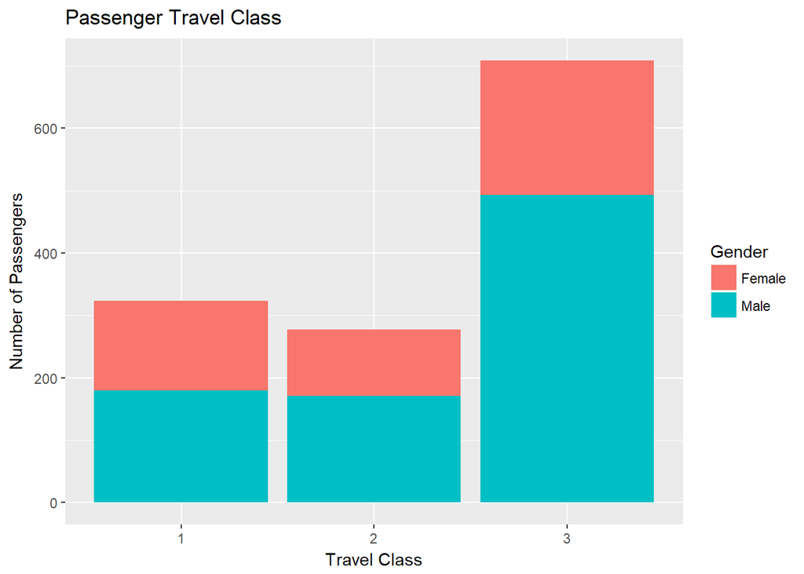

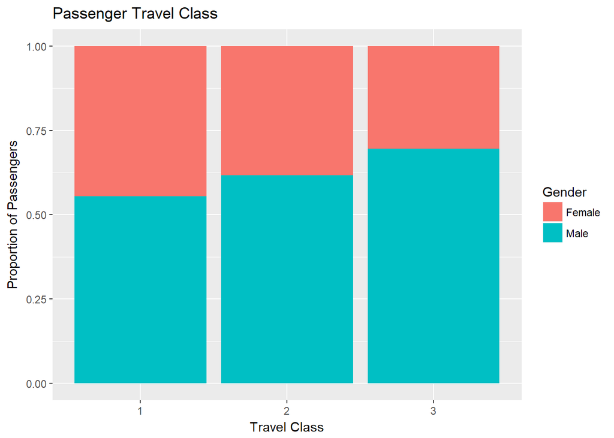

Here we notice that the greatest number of passengers were in third class, and the least number of passengers in second class. We can also see that there are more males than females within each class.

As we already noticed, most of the passengers embarked at Southampton:

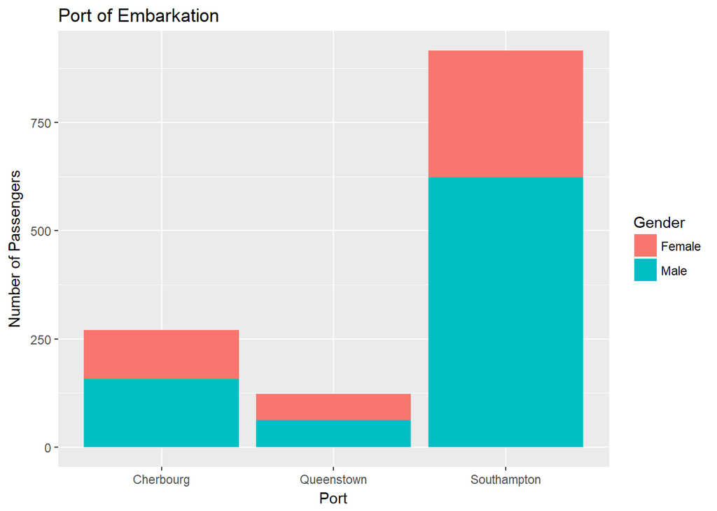

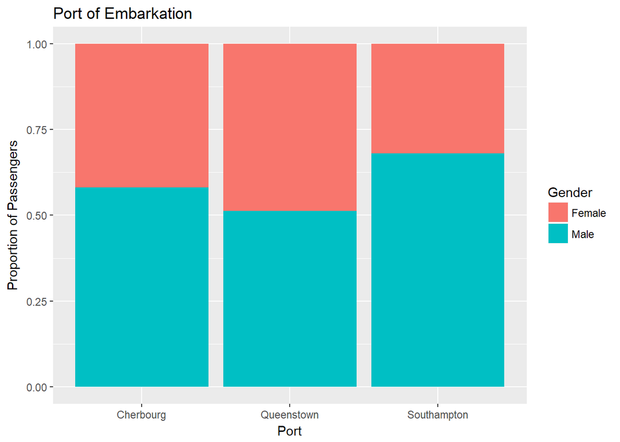

## Why so many unmarried women?

We already saw that there were more males than females on the Titanic, which isn’t unexpected. Each passenger also has a title (Mr., Mrs., etc.) and if we look at the distribution of titles among the passengers, we see something surprising:

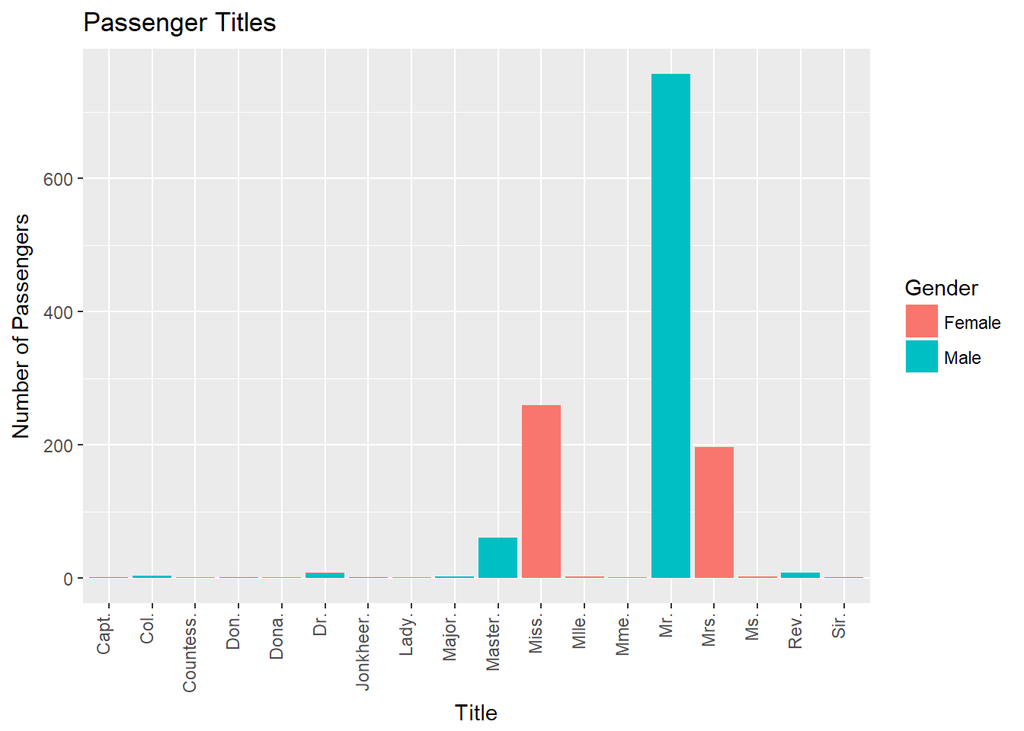

The largest group of women have the title Miss. We would expect these to be young, unmarried women traveling with their family.

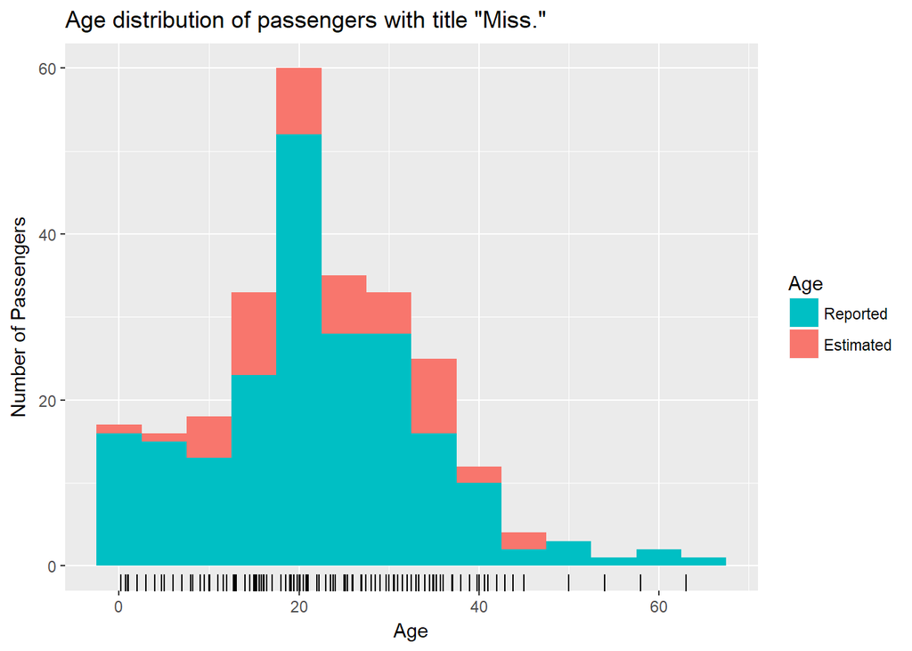

They do indeed seem to be young women with an average age of 22, Let’s look at the immediate family connections of the passengers with title “Miss”

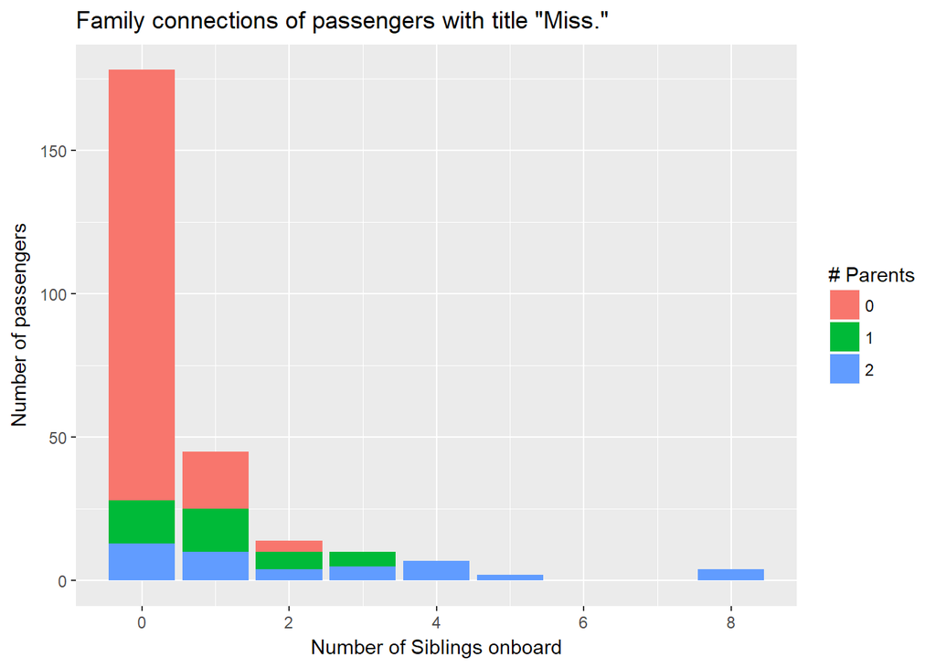

The majority of unmarried women (150) are not traveling with any immediate family member. At that time (1912) it seems unlikely that unmarried women would travel unaccompanied, so **who were these women traveling with?**

## Travel Class

One thing of note, is that both women with the unknown embarkation port have the same ticket number. We will explore the ticket numbers here to determine what information is contained in them.

## Duplicate ticket numbers

There are only 929 unique ticket numbers. This may be an indication of travelling group size. We explore a few permutations:

```r
titanic_data %>%
  group_by(ticket, familyname) %>%
  summarize(count = n()) %>%
  arrange(desc(count)) %>%
  head(10)
```

```
## Source: local data frame [10 x 3]
## Groups: ticket [10]
##
##      ticket familyname count
##       <chr>      <chr> <int>
## 1  CA. 2343       Sage    11
## 2   CA 2144    Goodwin     8
## 3    347077    Asplund     7
## 4    347082  Andersson     7
## 5     19950    Fortune     6
## 6   3101295     Panula     6
## 7    347088      Skoog     6
## 8    382652       Rice     6
## 9    349909    Palsson     5
## 10     4133    Lefebre     5
```

```r
titanic_data %>%
  group_by(ticket, familyname) %>%
  summarize(count = n()) %>%
  arrange(familyname) %>%
  head(10)
```

```
## Source: local data frame [10 x 3]
## Groups: ticket [10]
##
##              ticket  familyname count
##               <chr>       <chr> <int>
## 1         C.A. 5547      Abbing     1
## 2         C.A. 2673      Abbott     3
## 3            348122    Abelseth     1
## 4            348125    Abelseth     1
## 5         P/PP 3381     Abelson     2
## 6  SOTON/O2 3101284 Abrahamsson     1
## 7              2657     Abrahim     1
## 8            C 7076       Adahl     1
## 9            341826       Adams     1
## 10             7546       Ahlin     1
```

```r
titanic_data %>%
  group_by(ticket, familyname) %>%
  summarize(count = n()) %>%
  #arrange(familyname) %>%
  head(10)
```

```
## Source: local data frame [10 x 3]
## Groups: ticket [7]
##
##    ticket familyname count
##     <chr>      <chr> <int>
## 1  110152     Cherry     1
## 2  110152     Maioni     1
## 3  110152     Rothes     1
## 4  110413    Taussig     3
## 5  110465   Clifford     1
## 6  110465     Porter     1
## 7  110469    Maguire     1
## 8  110489   Borebank     1
## 9  110564 Bjornstrom     1
## 10 110813     Warren     2
```

Looking at the above results, we see some things to investigate futher: 1. Three unrelated people travelling on ticket 110152

```r
titanic_data %>%
  filter(ticket == 110152)
```

```
## # A tibble: 3 × 14
##   passengerid pclass
##         <int> <fctr>
## 1         258      1
## 2         505      1
## 3         760      1
## # ... with 12 more variables: name <chr>, sex <fctr>, age <dbl>,
## #   sibsp <int>, parch <int>, ticket <chr>, fare <dbl>, cabin <chr>,
## #   embarked <fctr>, title <fctr>, familyname <chr>, age_est <dbl>
```

Here we see three women traveling in first class, two of which are sharing a cabin. Exploring further, using the [Encyclopedia Titanica](https://www.encyclopedia-titanica.org/) an online directory of all passengers, We find that >The Countess [Rothes] boarded the Titanic at Southampton with her parents (travelling cross-channel only), her cousin Gladys Cherry and her maid Roberta Maioni.

2. Two people with the last name Abelseth travelling on different tickets

```r
titanic_data %>%
  filter(familyname == "Abelseth")
```

```
## # A tibble: 2 × 14
##   passengerid pclass                          name    sex   age sibsp
##         <int> <fctr>                         <chr> <fctr> <dbl> <int>
## 1         949      3 Abelseth, Mr. Olaus Jorgensen   male    25     0
## 2        1237      3   Abelseth, Miss. Karen Marie female    16     0
## # ... with 8 more variables: parch <int>, ticket <chr>, fare <dbl>,
## #   cabin <chr>, embarked <fctr>, title <fctr>, familyname <chr>,
## #   age_est <dbl>
```

Again, using the Encyclopedia Titanica we discover >Miss Abelseth was travelling with Olaus Abelseth (who, being a family friend, accompanied her but was no relation), Anna Salkjelsvik, Peter Søholt, Sigurd Hansen Moen and Adolf Humblen. So in this case, individuals travelling together do not have the same ticket number. 3. A large group with last name Sage all travelling on the same ticket

```r
titanic_data %>%
  filter(familyname == "Sage")
```

```
## # A tibble: 11 × 14
##    passengerid pclass                              name    sex   age sibsp
##          <int> <fctr>                             <chr> <fctr> <dbl> <int>
## 1          160      3        Sage, Master. Thomas Henry   male  7.60     8
## 2          181      3      Sage, Miss. Constance Gladys female  0.17     8
## 3          202      3               Sage, Mr. Frederick   male 41.40     8
## 4          325      3          Sage, Mr. George John Jr   male 48.50     8
## 5          793      3           Sage, Miss. Stella Anna female  9.50     8
## 6          847      3          Sage, Mr. Douglas Bullen   male 18.50     8
## 7          864      3 Sage, Miss. Dorothy Edith "Dolly" female 42.90     8
## 8         1080      3                   Sage, Miss. Ada female 34.00     8
## 9         1234      3             Sage, Mr. John George   male 30.70     1
## 10        1252      3       Sage, Master. William Henry   male 14.50     8
## 11        1257      3    Sage, Mrs. John (Annie Bullen) female 22.10     1
## # ... with 8 more variables: parch <int>, ticket <chr>, fare <dbl>,
## #   cabin <chr>, embarked <fctr>, title <fctr>, familyname <chr>,
## #   age_est <dbl>
```

In this case we see the Sage family (2 parents and 9 children) are indeed all traveling together on the same ticket.

From this exploration, we can conclude that individuals with the same ticket number are indeed travelling together, but there are also groups travelling together that do not share the same ticket number.

It is reasonable to assume that many of the seemingly unaccompanied women are travelling with other people, but perhaps not sharing the same ticket number.

### cut this section

Taking this information into account, we can eliminate the women traveling with the same ticket as another person:

```r
shared_ticket <-  titanic_data %>%
    group_by(ticket) %>%
    summarize(count = n()) %>%
    filter(count > 1)

titanic_data <- titanic_data %>%
  mutate(sharedticket = ifelse(ticket %in% shared_ticket$ticket, 1, 0))
```

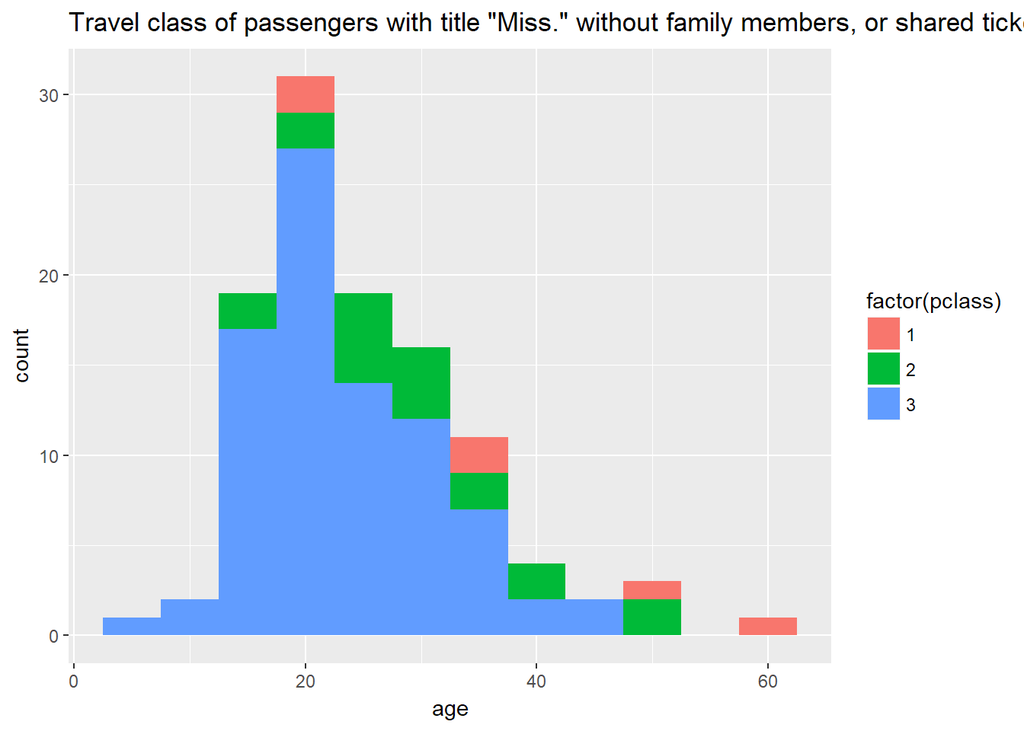

```r
titanic_data %>%
  filter(title == "Miss.",
         parch == 0,
         sibsp == 0,
         sharedticket == 0) %>%
  ggplot(aes(x = age, fill = factor(pclass))) +
  geom_histogram(binwidth = 5) +
  ggtitle('Travel class of passengers with title "Miss." without family members, or shared ticket')
```

# Age distributions of other Titles

For completeness, we look at the age distributions of each of the titles with the most individuals: Mr., Mrs., Master., Miss.

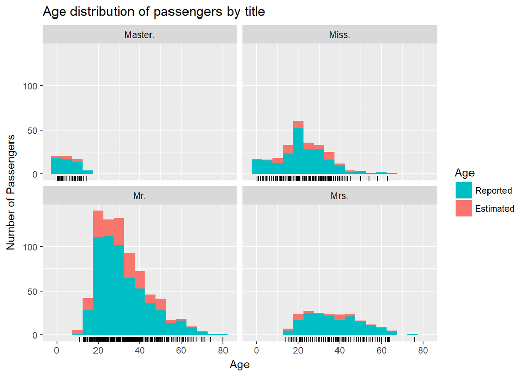

These results appear as we would expect, young males are given the title “Master”, and there are no very young women with the title “Mrs.” The wide range for the “Miss” title can be attributed to the fact that any unmarried woman is given that title regardless of age.

## Cabin

There are 1014 missing cabin values (out of 1309) entries, but we may still be able to learn something from this.

```r
# count missing cabin values:
#titanic_data %>%
#  filter(is.na(cabin)) %>%
#  summarize(n = n())
# 1014

# find shared tickets:
ticket_deck <-  titanic_data %>%
  filter(!is.na(cabin)) %>%
  distinct(ticket, .keep_all = TRUE) %>%
  select(ticket, cabin) %>%
  mutate(deck = substr(cabin, 0, 1)) %>%
  select(-cabin)


# fill in missing deck from same ticket
titanic_data <- titanic_data %>%
  merge(ticket_deck, by = "ticket", all.x = TRUE) %>%
  mutate(tdeck = substr(cabin, 0, 1),
         deck = ifelse(!is.na(tdeck), tdeck, deck),
         deck = ifelse(is.na(deck), "U", deck)) %>%
  select(-tdeck)
```

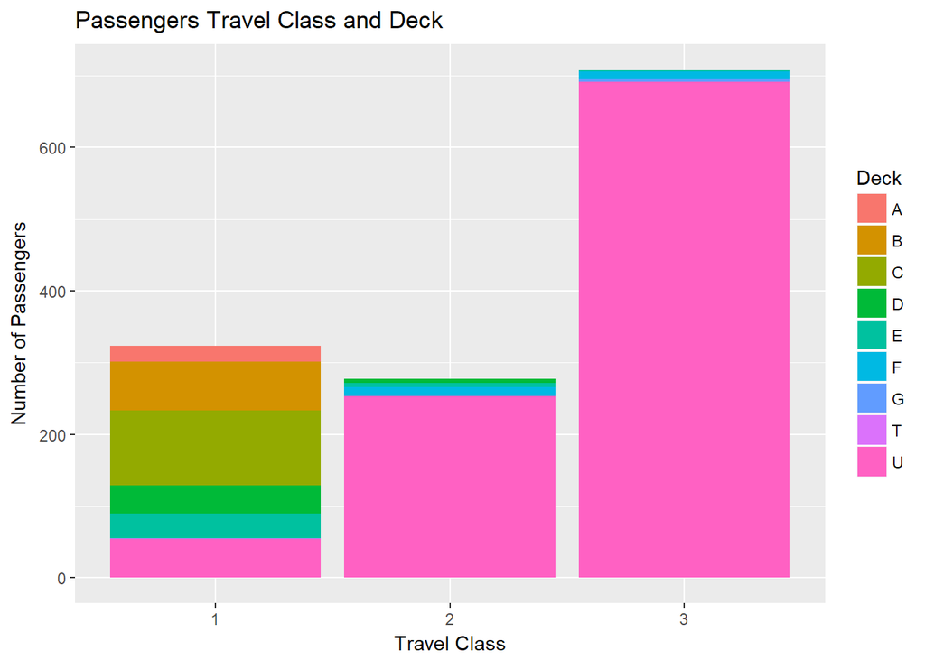

```r
ggplot(titanic_data, aes(x = pclass, fill = deck)) +
  geom_bar(position = "stack") +
  ggtitle("Passengers Travel Class and Deck") +
  labs(x = "Travel Class",
       y = "Number of Passengers") +
  scale_fill_discrete(name = "Deck")
```

# Ticket prices at Southampton

We know that the airlines change ticket prices dramatically in response to consumer activity, and track our online browsing to inflate the price for trips we’re interested in. Apparently this has been going on for a long time. Consider the ticket prices paid by the Titanic Passengers:

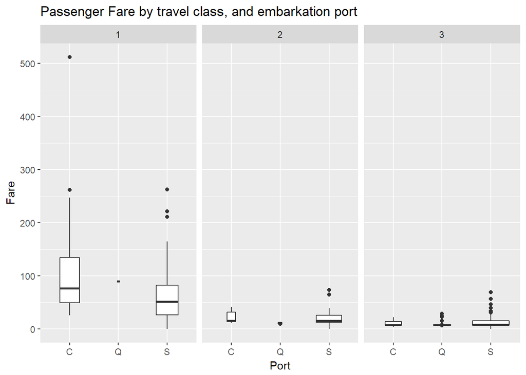

Here the widths of each box are proportional to the number of passengers represented. We see something interesting: some passengers boarding at Southampton paid more for second and third class travel than the median first class ticket from the same port. If we just look at the Southampton data, and break it down by gender:

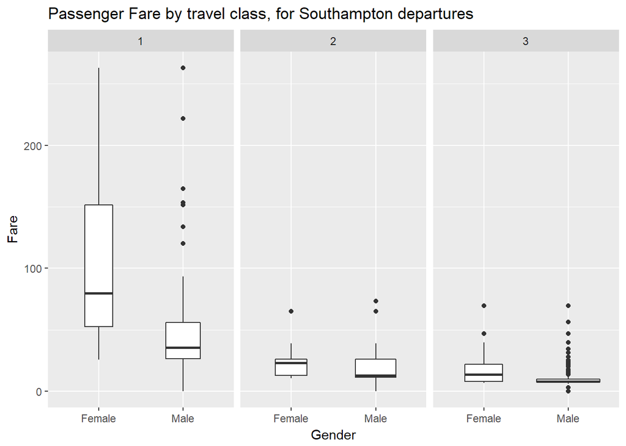

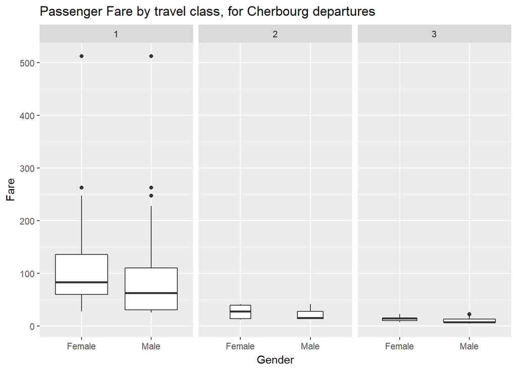

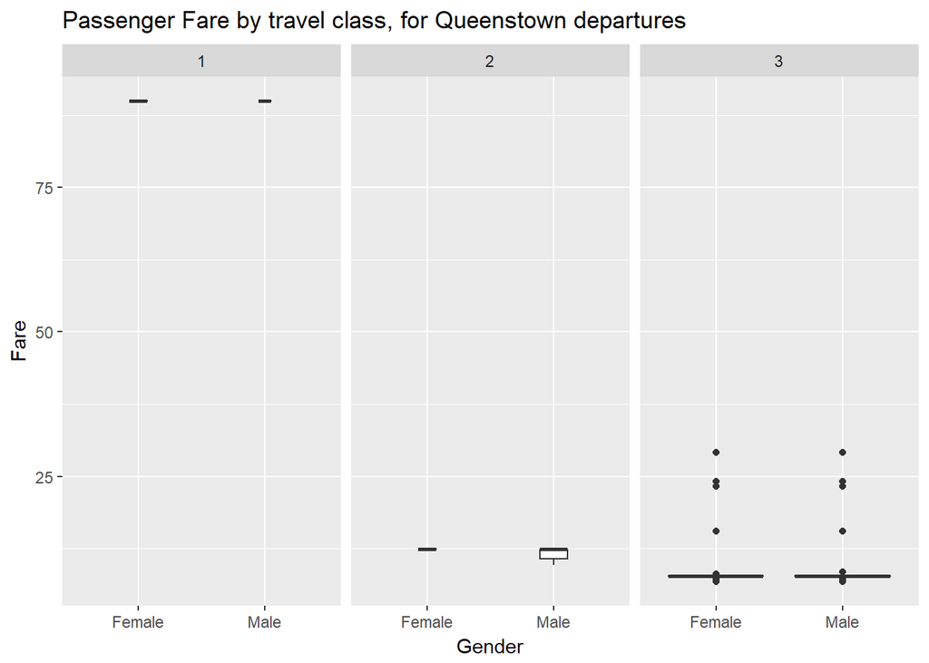

So what happened in Southampton? Perhaps looking at the fare as determined by title will help explain this:

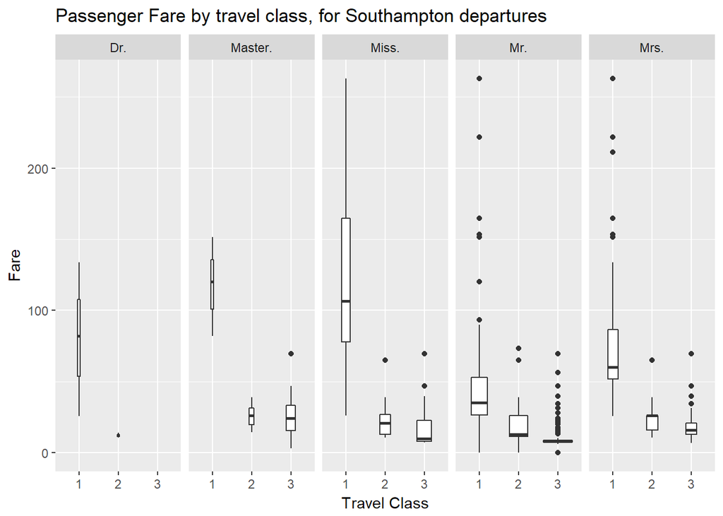

Interestingly, the group with the highest average fare is “Master”, or young boys less than 14 years old. However, note that it is a relatively few passengers with this title, especially in first class, and the range is well within the price paid by both the Mr. and Mrs. passengers. Investigating futher we see

```r
titanic_data %>%
  filter(title == "Master.",
         pclass == '1')
```

```
##     ticket passengerid pclass                                name  sex
## 1   113760         803      1 Carter, Master. William Thornton II male
## 2   113781         306      1      Allison, Master. Hudson Trevor male
## 3    16966        1088      1     Spedden, Master. Robert Douglas male
## 4    33638         446      1           Dodge, Master. Washington male
## 5 PC 17608         956      1         Ryerson, Master. John Borie male
##     age sibsp parch     fare           cabin embarked   title familyname
## 1 11.00     1     2 120.0000         B96 B98        S Master.     Carter
## 2  0.92     1     2 151.5500         C22 C26        S Master.    Allison
## 3  6.00     0     2 134.5000             E34        C Master.    Spedden
## 4  4.00     0     2  81.8583             A34        S Master.      Dodge
## 5 13.00     2     2 262.3750 B57 B59 B63 B66        C Master.    Ryerson
##   age_est sharedticket deck
## 1       0            1    B
## 2       0            1    C
## 3       0            1    E
## 4       0            1    A
## 5       0            1    B
```

These are indeed a few (5) children travelling with very wealthy families who paid high ticket prices.

Similarily, we see:

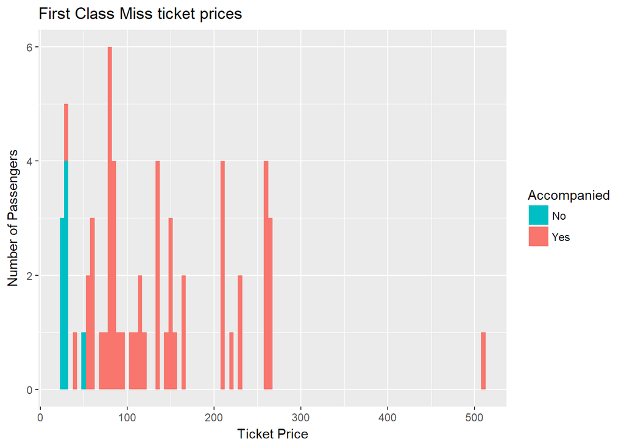

```r
titanic_data %>%
  filter(title == "Miss.",
         pclass == '1') %>%
  ggplot(aes(x = fare, fill = factor(sharedticket, levels = c(1, 0)))) +
  geom_histogram(binwidth = 5) +
  ggtitle('First Class Miss ticket prices') +
  scale_fill_discrete(name = "Accompanied",
                      breaks = c("0", "1"),
                      labels = c("No", "Yes")) +
  labs(x = "Ticket Price",
       y = "Number of Passengers")
```

The variation in travel costs for young people who typically don’t travel alone is therefore due to the range of wealth of their travelling companions, and the relatively small number of these individuals.

We still see some third class passengers who paid more than many first class passengers, and inconsistent pricing within each class depending on the passenger’s title. **How were passenger fares determined?**

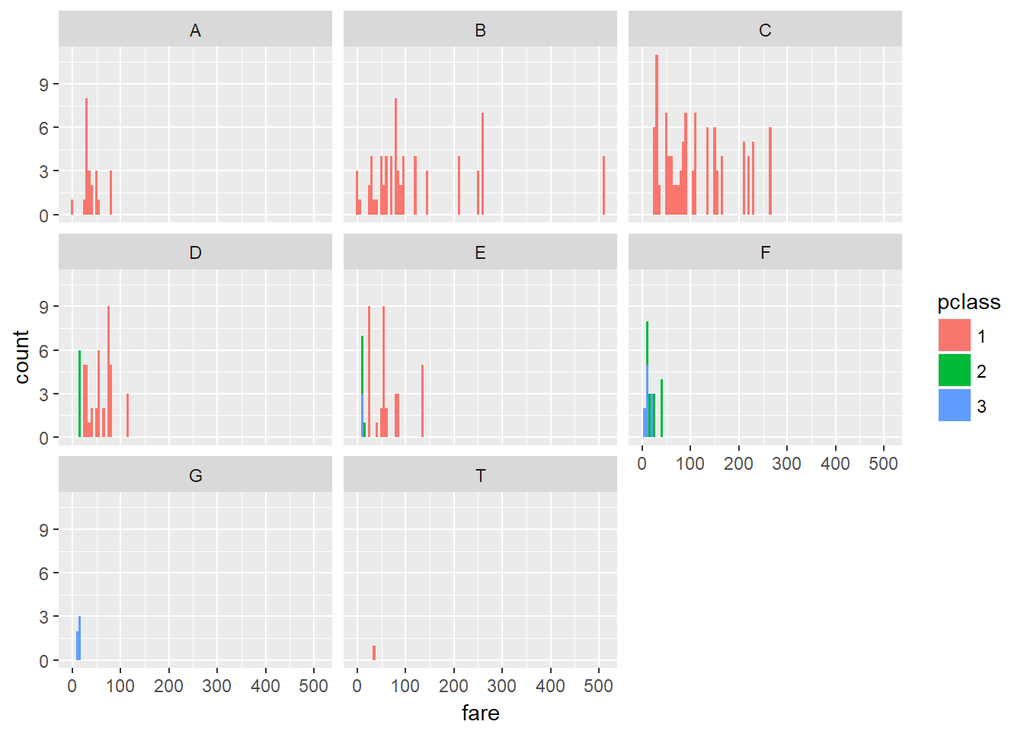

```r
titanic_data %>%
  filter(deck != "U") %>%
  ggplot(aes(x = fare, fill = pclass)) +
  geom_histogram(binwidth = 5) +
  facet_wrap(~ deck)
```

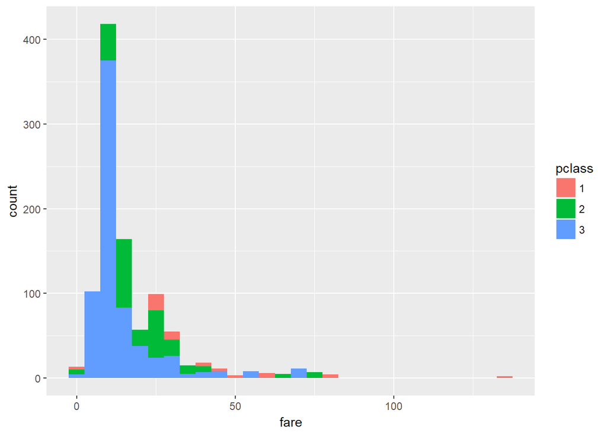

```r
titanic_data %>%
  filter(deck == "U") %>%
  ggplot(aes(x = fare, fill = pclass)) +
  geom_histogram(binwidth = 5)
```

# Conclusions

Through this exploratory analysis, we encountered two surprising trends in the data that suggested further avenues of investigation. and explored these things in more detail.

# What’s next?

As mentioned previously, the Titanic data set was obtained from a Kaggle competition to build a model that will predict a passenger’s survival. The next step will be to explore machine learning techniques and select an appropriate model for the passenger survival. Look for a followup project in the future.